# S3 Cultura asiática

Grupo 3

2022-06-24

# CONTENIDO

## Introducción

### 1.Relevancia

**Título:** Influencia de la cultura asiática en los gastos de entretenimiento en los estudiantes de UTEC durante la pandemia.

**Población objetivo:** Comunidad de UTEC que consume la cultura asiática y las que no.

**Contexto:** Debido al crecimiento del interés hacia las culturas asiáticas a nivel global han ido apareciendo muchas comunidades de fans en nuestro país. Es por ello que queremos saber que tanto a impactado este interés en nuestra población estudiantil.

**Objetivo:**

+ **Objetivo principal:** Determinar la influencia en los gastos en entretenimiento de los Utecsinos.

+ **Objetivos secundarios:**Determinar si los utecsinos fans de estas culturas gastan mas en entretenimiento que los utecsinos que no.

### 2.Planificación

**Diagrama de Gantt**

Para poder cumplir todos los objetivos de nuestro estudio, es necesaria tener la organización más eficiente posible, por eso es que hemos realizado el siguiente diagrama de Gantt con las actividades a realizar el ciclo 2022-1.

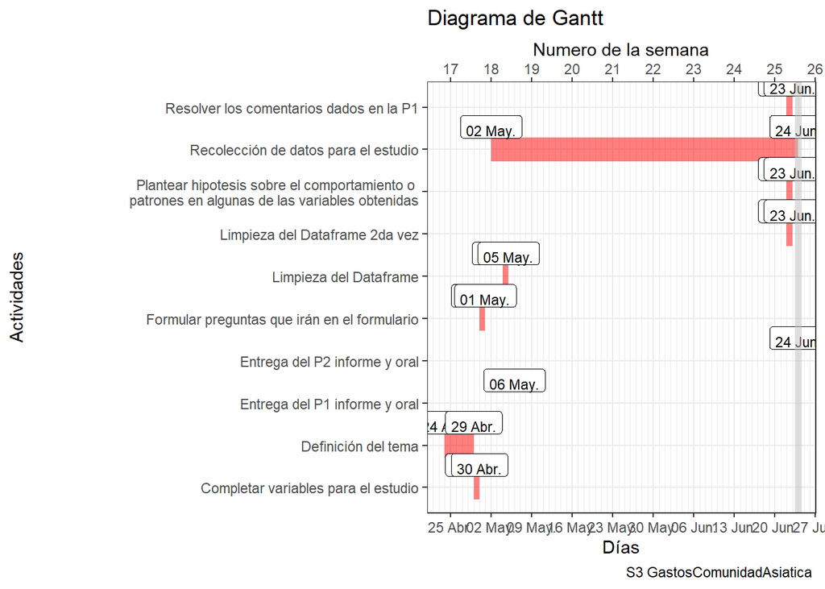

## Datos

### 3. Proceso de recolección de datos

1. Creación de un formulario mediante el uso de *Google Forms* (https://forms.gle/7bgh97rLTZJnrr476 ) con preguntas definidas de acuerdo al objetivo del estudio.
2. Difusión del cuestionario por la red social *Whatsapp*.
- Para esta entrega se estarán utilizando 201 unidades muestrales proporcionadas por el formulario que se utilizó para la recolección de datos.

### 4. Población, muestra y muestreo

- Nuestra población de estudio es la comunidad de estudiantes de UTEC que según Bienestar estudiantil tenemos a 2500 alumnos en nuestro plantel, y nuestra unidad de muestreo es el estudiante de UTEC regular matriculado este semestre.

### 5. Identificar y explicar el tipo de muestreo.

**5.1 Tipo de muestreo:** El tipo de muestreo es por conveniencia ya que la encuesta a sido realizada por nuestros conocidos o circulo cercano dentro de la universidad.

**5.2 Variables**

En este estudio se han planteado 11 variables, de las cuáles 5 son numéricas y 6 categóricas. A continuación en el siguiente cuadro se muestra a detalle cada variable.

[output not shown]

**5.3 Limpieza de base de datos**

En primer lugar,se eliminan los datos que no son relevantes para el estudio como la marca temporal de las encuestas y el correo electrónico. Luego, se cambia el nombre de las variables restantes, ya que muchas de ellas están formuladas como preguntas extensas para la recolección de la información. Finalmente, con los datos restantes se puede analizar el objetivo de la investigación el cual es relacionar la influencia de la cultura asiática en el gasto mensual de los estudiantes de UTEC en entretenimiento y la comparación entre variables.

5.3.1. Código de limpieza

Leer DataFrame

```r
influ  <- read_csv("Influencia_Cultura_asiatica.csv")
```

Sacar variables que no sirven ( Marca Temporal y Dirección)

```r
dfP <- influ[,3:13]
```

5.3.2. Cambiar nombre de variables con rename

```r
#nombre por el que quiero cambiar = nombre original
#asignación a la izquierda (->)
dfP %>% rename( Genero = `Género`,  IM = `Ingresos mensuales (Trabajo, mesadas, propinas)`, PrincipalEntrete = `¿Cuál es tu forma principal de entretenimiento?` , FrecuenActv = `Con que frecuencia realizas esta actividad mensualmente` , GastosMen = `¿ Cuánto gastas en promedio aproximadamente mensual?` , TiempoSem = `¿Cuánto tiempo gastas semanalmente realizando dicha actividad?`  , ConocesCul = `¿ Conoces sobre la cultura asiática?` , Pais =  `¿De qué país asiático consumes entretenimiento?` , ConsiFan = `¿ Te consideras fan de esta cultura?`) -> DFN
```

Como define R las variables, están de una forma correcta

```r
str(DFN)
```

```
## tibble [201 x 11] (S3: tbl_df/tbl/data.frame)
##  $ Edad            : num [1:201] 23 20 20 19 19 17 20 18 17 18 ...
##  $ Genero          : chr [1:201] "Masculino" "Femenino" "Masculino" "Masculino" ...
##  $ IM              : num [1:201] 4300 580 50 50 1100 0 1200 0 1000 920 ...
##  $ Carrera         : chr [1:201] "Ingeniería Industrial" "Ingeniería Ambiental" "Bioingeniería" "Ingeniería Mecánica" ...
##  $ PrincipalEntrete: chr [1:201] "Salir a comer" "Coleccionar (álbumes, monedas, juguetes, etc)" "Ver series / videos/ novelas" "Ver series / videos/ novelas" ...
##  $ FrecuenActv     : num [1:201] 4 3 30 60 30 5 20 2 3 4 ...
##  $ GastosMen       : num [1:201] 300 40 200 0 120 500 500 920 600 800 ...
##  $ TiempoSem       : num [1:201] 8 6 7 96 28 5 6 300 15 4 ...
##  $ ConocesCul      : chr [1:201] "Sí conozco" "Sí conozco" "Sí conozco" "No conozco" ...
##  $ Pais            : chr [1:201] NA "Korea" "Japón" "Japón" ...
##  $ ConsiFan        : chr [1:201] "No" "Sí" "Sí" "No" ...
```

5.3.3. Cambiar nombre de las opciones de entretenimiento para una mejor visualización

```r
DFN$PrincipalEntrete[DFN$PrincipalEntrete=="Ir de compras"] <-"Compras"
DFN$PrincipalEntrete[DFN$PrincipalEntrete=="Salir a comer"] <-"Comer"
DFN$PrincipalEntrete[DFN$PrincipalEntrete=="Meet ups"] <-"Encuentros"
DFN$PrincipalEntrete[DFN$PrincipalEntrete=="Ver series / videos/ novelas"] <-"Series"
DFN$PrincipalEntrete[DFN$PrincipalEntrete=="Coleccionar (álbumes, monedas, juguetes, etc)"] <-"Coleccion"
DFN$PrincipalEntrete[DFN$PrincipalEntrete=="Videojuegos"] <-"Videojuegos"
DFN$PrincipalEntrete[DFN$PrincipalEntrete=="Leer historietas, mangas, manhwas, manhuas, etc"] <-"Leer"
DFN$PrincipalEntrete[DFN$PrincipalEntrete=="Ir al cine"] <-"Cine"
```

5.3.4. Cambiar nombre de las opciones de carrera para una mejor visualización

```r
DFN$Carrera[DFN$Carrera=="Ingeniería Industrial"] <-"IND"
DFN$Carrera[DFN$Carrera=="Ingeniería de la Energía"] <-"EN"
DFN$Carrera[DFN$Carrera=="Ingeniería Civil"] <-"CIV"
DFN$Carrera[DFN$Carrera=="Ingeniería Química"] <-"QUI"
DFN$Carrera[DFN$Carrera=="Ingeniería Electrónica"] <-"EL"
DFN$Carrera[DFN$Carrera=="Ingeniería Mecánica"] <-"MC"
DFN$Carrera[DFN$Carrera=="Ingeniería Ambiental"] <-"AM"
DFN$Carrera[DFN$Carrera=="Ingeniería Mecatrónica"] <-"MT"
DFN$Carrera[DFN$Carrera=="Bioingeniería"] <-"BIO"
DFN$Carrera[DFN$Carrera=="Ciencia de la Computación"] <-"CS"
DFN$Carrera[DFN$Carrera=="Administración y negocios digitales"] <-"AYN"
DFN$Carrera[DFN$Carrera=="Ciencia de Datos"] <-"CD"
```

## Analisis Descriptivo

### 6. Descriptores numéricos

**6.1 Análisis de la variable GastosMen (gasto mensual)**

La variable GastosMen(gasto promedio mensual de los estudiantes) es la más importante, ya que es la que se va a relacionar con los tipos de entretenimiento de nuestro estudio.

Con la función summary podemos obtener la mediana y media con los rangos intercuartiles de la variable solicitada

```
##    Min. 1st Qu.  Median    Mean 3rd Qu.    Max.
##     0.0    65.0   200.0   319.4   400.0  4000.0
```

Desviación estándar

```
## [1] 521.3023
```

Moda

```
## [1] 200
```

**6.2 Análisis de la variable Frecuencia de actividades (mensual)**

Con la función summary podemos obtener la mediana y media con los rangos intercuartiles de la variable solicitada

```
##    Min. 1st Qu.  Median    Mean 3rd Qu.    Max.
##    1.00    4.00    7.00   11.41   13.00   60.00
```

Desviación estándar

```
## [1] 11.83946
```

Moda

```
## [1] 10
```

## Analisis descriptivo

### 7. Sacamos el outlier

```
## [1] 80
```

```
## # A tibble: 200 x 11
##     Edad Genero      IM Carrera PrincipalEntrete FrecuenActv GastosMen TiempoSem
##    <dbl> <chr>    <dbl> <chr>   <chr>                  <dbl>     <dbl>     <dbl>
##  1    20 Femenino   580 AM      Coleccion                  3        40         6
##  2    20 Masculi~    50 BIO     Series                    30       200         7
##  3    19 Masculi~    50 MC      Series                    60         0        96
##  4    19 Femenino  1100 IND     Leer                      30       120        28
##  5    17 Femenino     0 IND     Compras                    5       500         5
##  6    20 Masculi~  1200 MT      Videojuegos               20       500         6
##  7    18 Femenino     0 CS      Compras                    2       920       300
##  8    17 Femenino  1000 IND     Compras                    3       600        15
##  9    18 No bina~   920 IND     Series                     4       800         4
## 10    19 Masculi~   100 MT      Videojuegos               26        50        78
## # i 190 more rows
## # i 3 more variables: ConocesCul <chr>, Pais <chr>, ConsiFan <chr>
```

### 8. Datos faltantes y observaciones completas

- Observaciones incompletas

```
## [1] 19
```

- Datos Faltantes

```
## [1] 19
```

### 9. Descriptores gráficos

**GRAFICO 0 -> CARRERAS CON MAYOR PARTICIPACION**

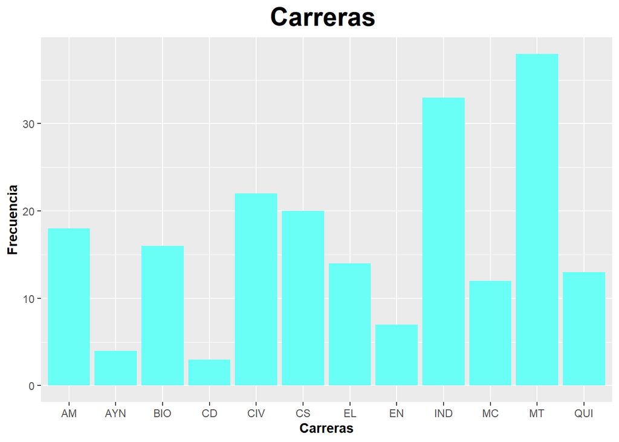

**Comentario 0:**  
De la gráfica se observa que los alumnos de la carrera ingeniería mecatrónica tienen una mayor participación en nuestra encuesta. Además observamos que los estudiantes de la carrera Ciencia de datos tienen menos participación en nuestra encuesta

**GRAFICO 1 -> INGRESO MENSUAL VS GASTO MENSUAL**

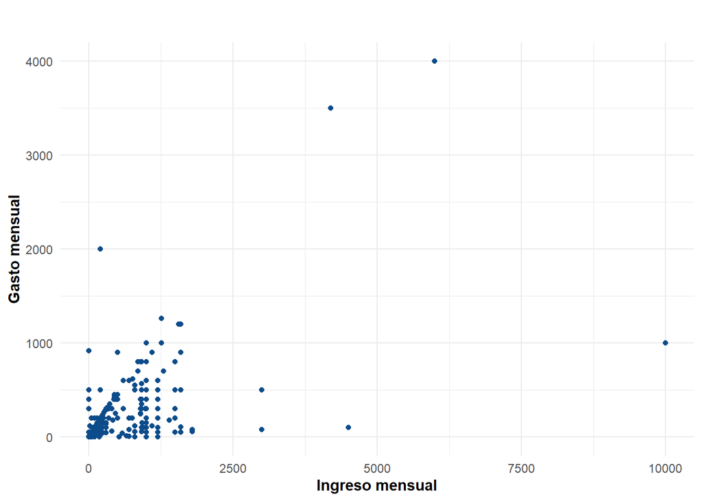

**Correlación aceptable mayor que 0.5**

```
##
##  Pearson's product-moment correlation
##
## data:  dfP2$IM and dfP2$GastosMen
## t = 10.644, df = 198, p-value < 2.2e-16
## alternative hypothesis: true correlation is not equal to 0
## 95 percent confidence interval:
##  0.5069584 0.6847009
## sample estimates:
##      cor
## 0.603268
```

**Comentario 1:** El gráfico 1 a diferencia del anterior ahora podemos notar una tendencia pero para poder corroborar debemos de hallar la correlación, la correlación de este es del 0.60. Para el curso se pide un mínimo de 0.5 para que pueda haber una relación entre dos variables. En este caso se puede observar un **patrón** donde los que tiene mayor ingreso mensual llegan a gastar mas en entretenimiento al mes

**GRAFICA 2 -> Fanatismo VS GASTO MENSUAL**

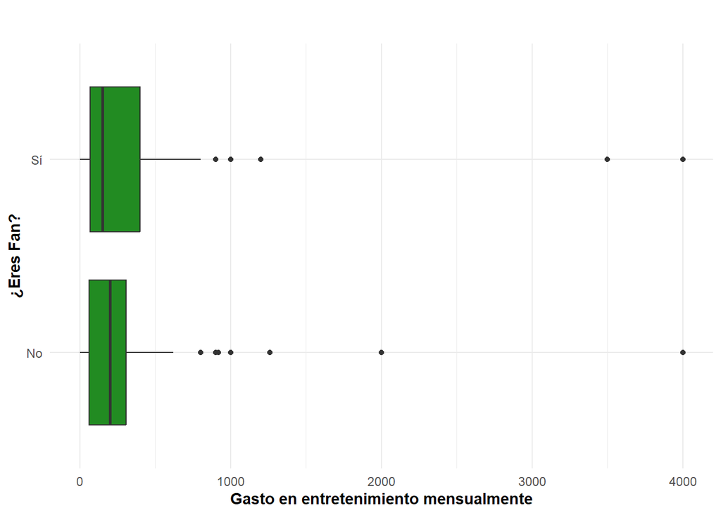

**GRAFICA 3 -> FANATISMO VS TIEMPO EN LOS DIFERENTES ENTRETENIMIENTOS POR SEMANA**

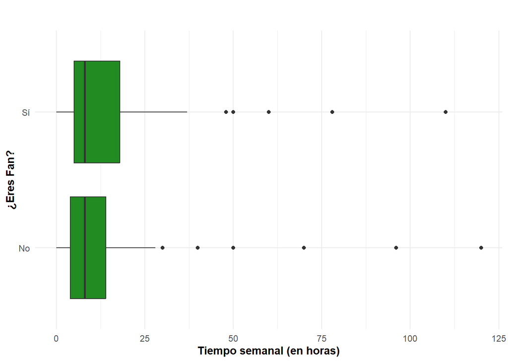

**Comentario 3:** De esta gráfica se puede concluir que las personas fanáticas y las no fanáticas gastan una cantidad minimamente diferente de tiempo en actividades de entretenimiento semanal.

**GRAFICA 4 -> ENTRETENIMIENTO VS GASTO MENSUAL**

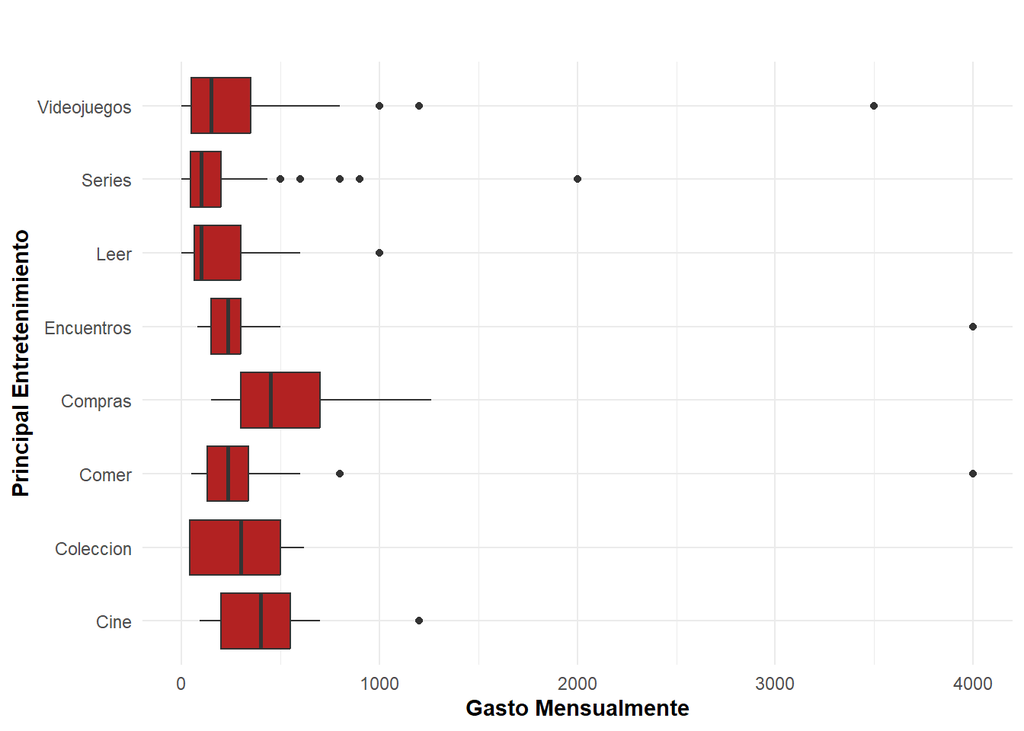

**Comentario 4:** De esta gráfica concluimos que los entretenimientos como videojuegos, ver series y leer son los que generan menor gasto mensual en los estudiantes de UTEC, por el contrario en las compras(ropa,accesorios,etc) llegan a gastar mas de 1000 soles al mes.

**GRAFICA 5 -> GRÁFICOS DE ENTRETENIMIENTO DE FANS Y NO FANS**

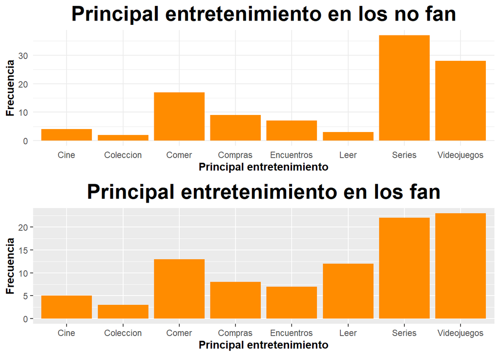

*Comentario 5:* En esta gráfica observamos que los Fanáticos consumen mas entretenimiento donde el gasto mensual es menor como Series y Videojuegos, por ende consumen menos en los entretenimientos caros. Además, podemos observar que los no fanáticos consumen mas entretenimiento en ver series, pero casi lo mismo en videojuegos que los fanáticos.

**GRAFICA 6 -> FANATISMO VS INGRESOS MENSUALES**

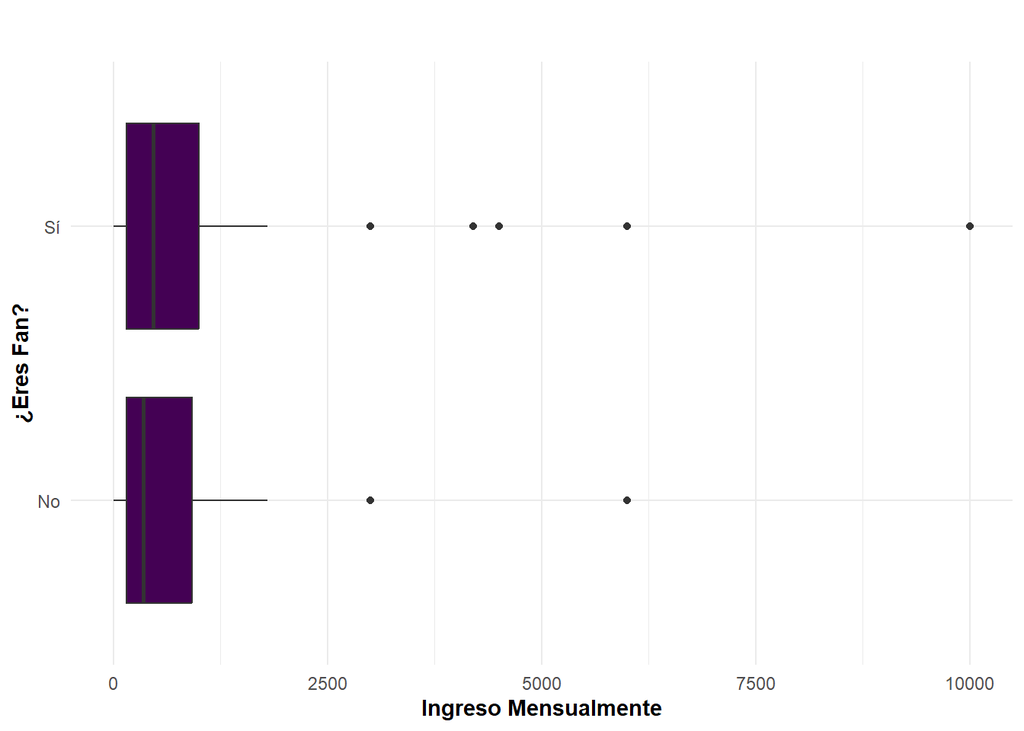

*Comentario 6:* En este gráfico vemos que los estudiantes que sí son fanáticos tienen mayores ingresos que los no fanáticos. Estas variables no tienen necesariamente una relación causal entre sí, pero pueden ayudar a entender mejor el análisis de los gastos mensuales de cada uno.

**GRAFICA 7 -> GENERO VS FANATISMO**

```
##
##              No Sí
##   Femenino   35 46
##   Masculino  69 47
##   No binario  3  0
```

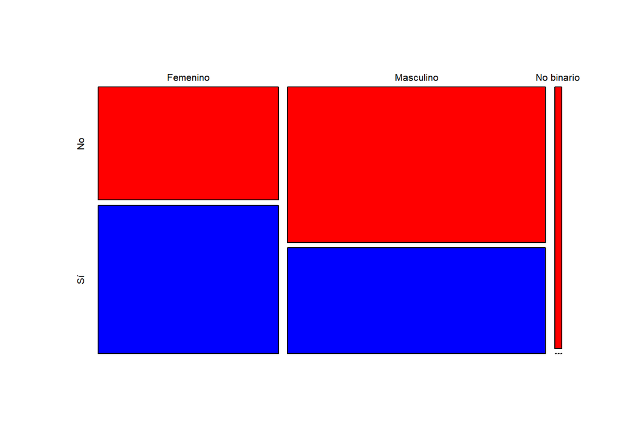

**Comentario 7:** En este mosaico podemos observar que el porcentaje de mujeres que son fanáticos es mayor que el porcentaje de hombres que son fanáticos. Los hombres tienen una mayor participación en la encuesta, sin embargo pocos se consideran fanáticos.

**GRAFICA 8 -> DÍAS AL MES DE LAS ACTIVIDADES MÁS REALIZADAS POR PAÍS DE LAS PERSONAS QUE SÍ SE CONSIDERAN FANS**

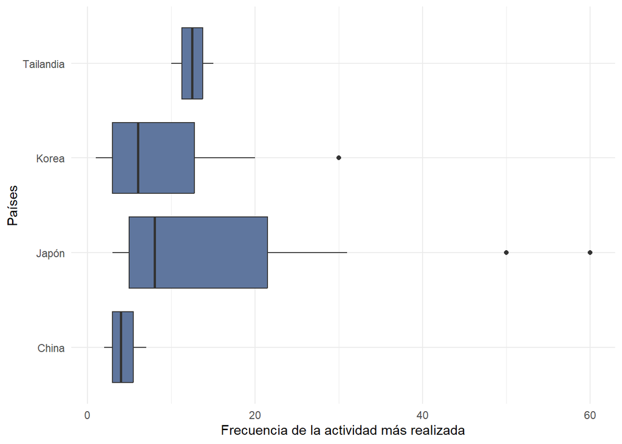

**Comentario 8:** Con este gráfico podemos observar que las personas fans que consumen entretenimiento de Tailandia son las que realizan su actividad con mas frecuencia al mes.Por el contrario las personas fans que consumen entretenimiento de China son las que realizan su actividad con menos frecuencia al mes

## Análisis probabilistico

### 10. Modelos que podrían representar a las variables

**Variables Aleatorias**

**10.1 Variable discreta- ¿Te consideras fan?**

La variable “¿ Te consideras fan de esta cultura?” solo presenta dos posibles eventos independientes y es una de la mas importantes en nuestro estudio ya que divide en los 2 grupo de interés las personas que son fan y las que no.

Se observa que con la variable ¿ Te consideras fan de esta cultura? podemos realizar un análisis probabilistico con modelo geométrico.

- **10.1.1 Uso de la distribución geométrica**
- Total de encuestados:

```
## [1] 200
```

```
##
##  No  Sí
## 107  93
```

- Número de personas que si son fan:

```
## [1] 93
```

Número de encuestados = 200

- Probabilidad de que 1 persona sea fan:

```
## [1] 0.465
```

**Experimento:** Cual es la probabilidad de que una persona sea fan de la cultura asiática en la prueba 2

**k: Numero de pruebas antes de tener el primer éxito**

**p: probabilidad de éxito**

**Éxito: que sea fanático de la cultura asiático**

x~geom(k,p)<->P(x)

k=2-1

p=0.465

```r
k<-1
dgeom(1,p)
```

```
## [1] 0.248775
```

Resultado: La probabilidad de que en la prueba 2 la persona es fanática de la cultura asiática es 0.25 .

**10.2 Variable discreta- Ingresos mensuales(IM)**

Esta es una variable aleatoria discreta. Debido a que el gasto mensual es una variable de importancia y está estrechamente relacionada con el ingreso mensual de los alumnos de UTEC, se ha considerado pertinente analizar la variable Ingreso mensual (IM).

Análisis probabilístico Esta variable puede encajar en varios modelos dependiendo de cómo se observe. En este caso se va a analizar como una distribución de probabilidad Hipergeométrica.

- **Uso de la distribución hipergeométrica**

Total de datos completados:

```
## [1] 200
```

Utilizamos la “dhyper” y se toman en cuenta las siguientes consideraciones:

-La característica de interés serán los ingresos mayores o iguales a 800 soles (éxito si IM>=800 y fracaso si IM<800)

-La “muestra” dentro de este ejemplo será de 70 alumnos

-La cantidad de alumnos que se buscan con dichos ingresos es de 20

```
##
##    0   10   20   50   60   80   90  100  125  135  150  160  180  195  200  210
##   11    1    3    9    2    3    2   12    1    1    9    1    2    1   12    1
##  215  225  235  240  243  250  260  265  280  300  320  350  365  400  420  440
##    1    2    1    1    1    3    1    1    1    8    2    4    1    2    1    1
##  450  465  500  530  580  600  650  700  750  765  800  850  900  920  930  950
##    3    2    9    1    1    2    1    4    1    1    5    2    5    8    1    1
##  980 1000 1100 1200 1260 1300 1400 1500 1560 1600 1800 3000 4200 4500 6000 9999
##    1   15    2    9    2    1    1    5    1    5    2    2    1    1    2    1
```

Al utilizar el prefijo “d” se tiene en cuenta que la probabilidad representa que se encuentren exactamente 20 personas con ingresos de 800 soles o más.

```r
dhyper(20,74,127,70)
```

```
## [1] 0.02572479
```

```r
choose(74,20)*choose(127,50)/choose(201,70)
```

```
## [1] 0.02572479
```

También se ha calculado utilizando la definición y ambos resultados coinciden. Resultado: 0.02572479

**10.3 Variable Nominal - ¿ Conoces sobre la cultura asiática?**

Dicha variable solo muestra 2 posibles eventos independientes.Además se puede realizar un análisis probabilistico binomial

Total de encuestados:

```
## [1] 200
```

Tabla de resultados (Si o No)

```
##
## No conozco Sí conozco
##         44        156
```

Agregamos la cantidad de personas que conocen a un objeto

```
## [1] 156
```

Probabilidad de que 1 persona conozca sobre la cultura asiática:

```
## [1] 0.78
```

**Experimento:** En un grupo de alumnos, se sabe que el 78% conoce sobre la cultura asiática. Calcule la probabilidad de que en un grupo de 8 alumnos, 3 de ellos sí conozcan.

**x: Número de éxitos a obtener**

**n: Número de pruebas de Bernoulli**

**p: Probabilidad de éxito para cada una de las pruebas**

**Éxito: Que conozca sobre la cultura asiática**

dbinom(x,n,p)

x = 3

n = 8

p = 0.78

```r
dbinom(3,8,0.78)
```

```
## [1] 0.01369573
```

**Resultado:**

La probabilidad de que 3 alumnos de un grupo de 8 personas conozcan sobre la cultura asiática es de 0.013.

### 11. Regresión lineal

#11.1 Modelo de regresión linea simple para los gastos mensuales con respecto a los ingresos mensuales

```
##
## Call:
## lm(formula = GastosMen ~ IM, data = dfP2, na.action = na.exclude)
##
## Residuals:
##      Min       1Q   Median       3Q      Max
## -2055.40  -126.62   -47.44    96.12  2152.26
##
## Coefficients:
##              Estimate Std. Error t value Pr(>|t|)
## (Intercept) 110.93412   35.45386   3.129  0.00202 **
## IM            0.29448    0.02767  10.644  < 2e-16 ***
## ---
## Signif. codes:  0 '***' 0.001 '**' 0.01 '*' 0.05 '.' 0.1 ' ' 1
##
## Residual standard error: 417.9 on 198 degrees of freedom
## Multiple R-squared:  0.3639, Adjusted R-squared:  0.3607
## F-statistic: 113.3 on 1 and 198 DF,  p-value: < 2.2e-16
```

Comentario: En el summary podemos observar que el r cuadrado nos da 0.3639, este r cuadrado o coeficiente de determinación nos da el nivel de confianza y nos da un valor muy bajo ya que está lejos al 1. Ya que si está más cerca a 1 es mucho mas confiable. Esto podría ser debido a que halla otras variables que puedan estar influyendo en los gastos mensuales. Pero si hay una relación entre ellas

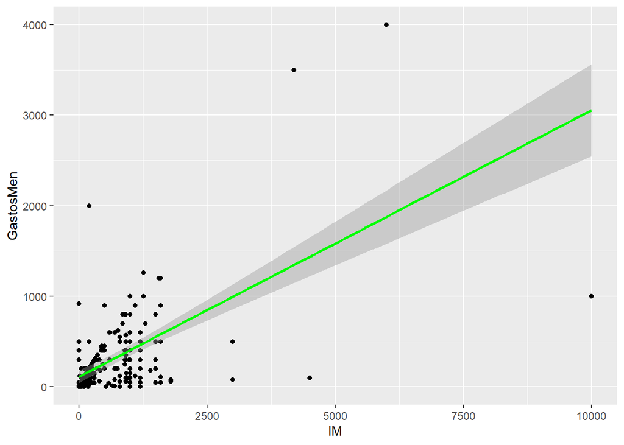